# network visualization with R

饶一率翻译整理

2023/8/13

### 5 除了`igraph`其他包`Statnet`，`ggraph`，`simple charts`

本节提供了一些快速示例，说明静态网络可视化的其他可用方法

#### 5.1 Statnet包网络示例

Statnet是R语言中的一个著名网络分析包,全名为“Statistical Analysis of Network Data”, 提供了网络数据的转换、模型拟合、预测、可视化等功能。 Statnet作为网络科学中重要的R语言工具包,拥有广泛的用户基础,包括:

- 网络科学研究人员:使用Statnet进行网络数据分析、建模等研究工作。
- 数据科学家:利用Statnet在R中进行网络分析。
- 生物信息学研究人员:分析生物分子网络和互作网络。
- 社会学家:分析社会关系网络。
- 程序员:基于Statnet开发新的网络分析工具。
- 学生:使用Statnet学习网络科学。

`Statnet`包家族包括`network`, `sna`, `ergm`, `stergm`等

```r
library('network')
nodes <- read.csv("Dataset1-Media-Example-NODES.csv", header=T, as.is=T)
links <- read.csv("Dataset1-Media-Example-EDGES.csv", header=T, as.is=T)

net4 <- network(links,  vertex.attr=nodes, matrix.type="edgelist",
                loops=T, multiple=F, ignore.eval = F)

# 在这里，我们可以很容易地访问边，顶点和网络矩阵:
#net4[,]
net4 %n% "net.name" <- "Media Network"
net4 %v% "media"
```

```
##  [1] "NY Times"            "Washington Post"     "Wall Street Journal"
##  [4] "USA Today"           "LA Times"            "New York Post"
##  [7] "CNN"                 "MSNBC"               "FOX News"
## [10] "ABC"                 "BBC"                 "Yahoo News"
## [13] "Google News"         "Reuters.com"         "NYTimes.com"
## [16] "WashingtonPost.com"  "AOL.com"
```

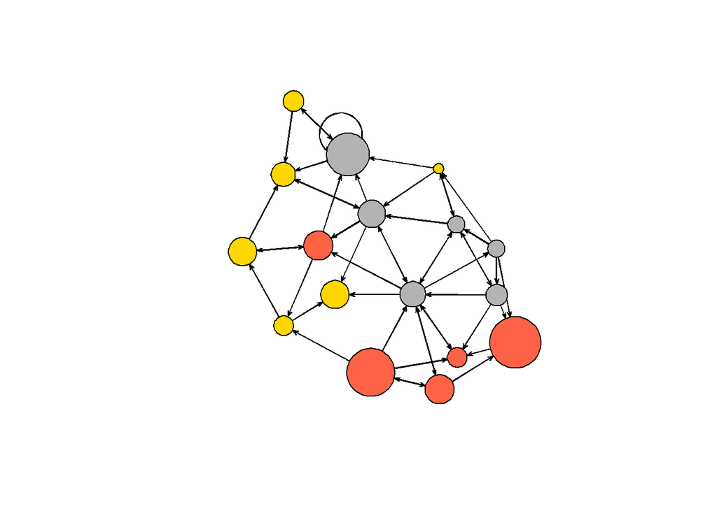

```r
#net4 %e% "type"
net4 %v% "col" <- c("gray70", "tomato", "gold")[net4 %v% "media.type"]
plot(net4, vertex.cex=(net4 %v% "audience.size")/7, vertex.col="col")
```

```r
detach('package:network')
```

#### 5.2 ggplot2包网络示例

`ggraph`包和`ggplot2`包的基本构建原理是一样的逻辑。 一个好消息是，我们可以直接在`ggraph`包中使用我们的`igraph`对象。下面的代码获取数据并为节点和链接添加单独的层。

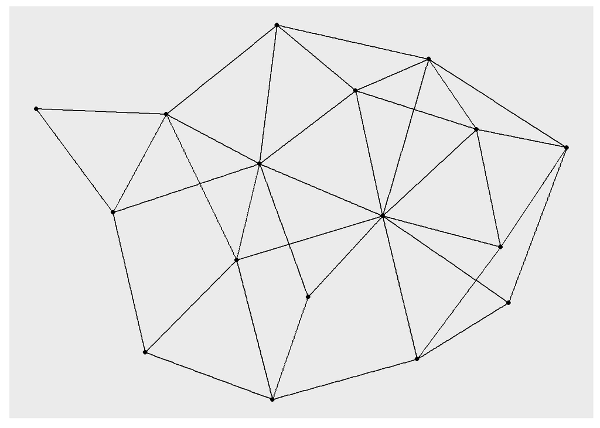

```r
library(ggraph)
library(igraph)
net <- graph_from_data_frame(d=links, vertices=nodes, directed=T)
colrs <- c("gray50", "tomato", "gold")
V(net)$color <- colrs[V(net)$media.type]
#par(mfrow=c(2,2), mar=c(0,0,0,0))
ggraph(net) +
  geom_edge_link() +
  geom_node_point()
```

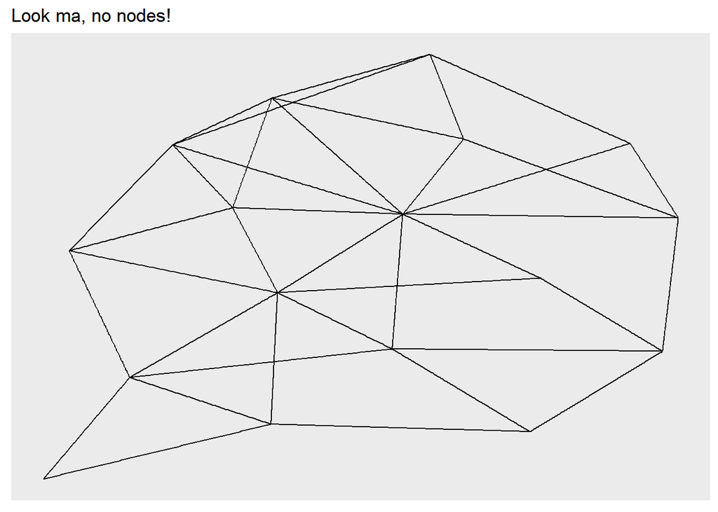

```r
# 加上布局，标题
ggraph(net, layout="lgl") +
  geom_edge_link() +
  ggtitle("Look ma, no nodes!")
```

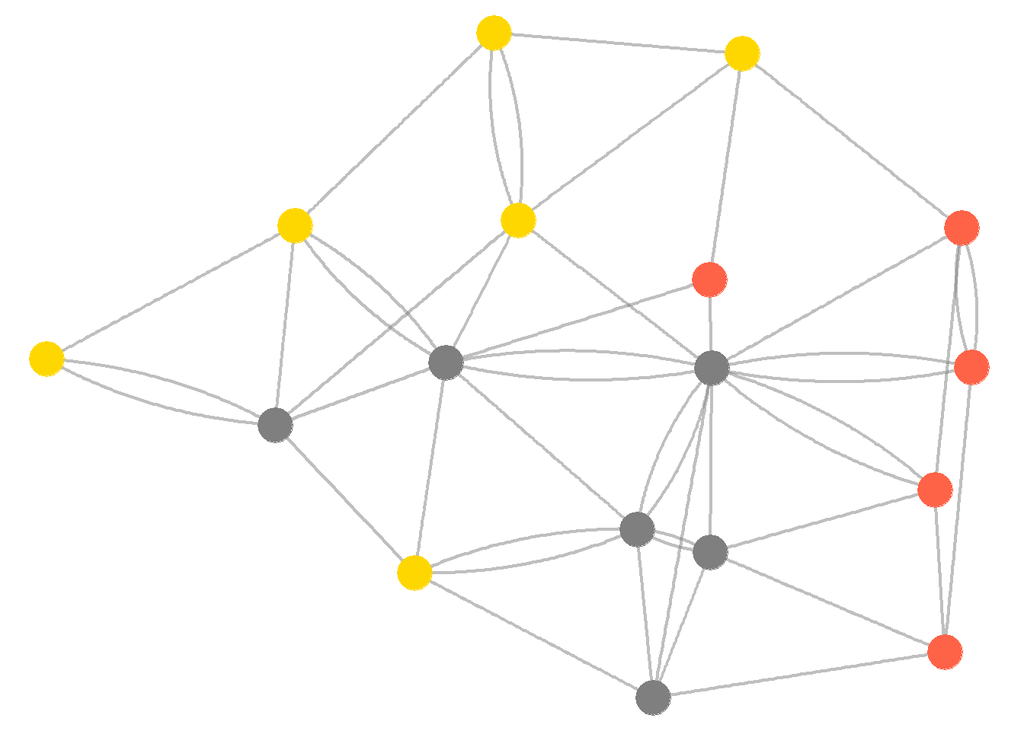

```r
# 加上边的格式
ggraph(net, layout="lgl") +
  geom_edge_fan(color="gray50", width=0.8, alpha=0.5) +
  geom_node_point(color=V(net)$color, size=8) +
  theme_void()
```

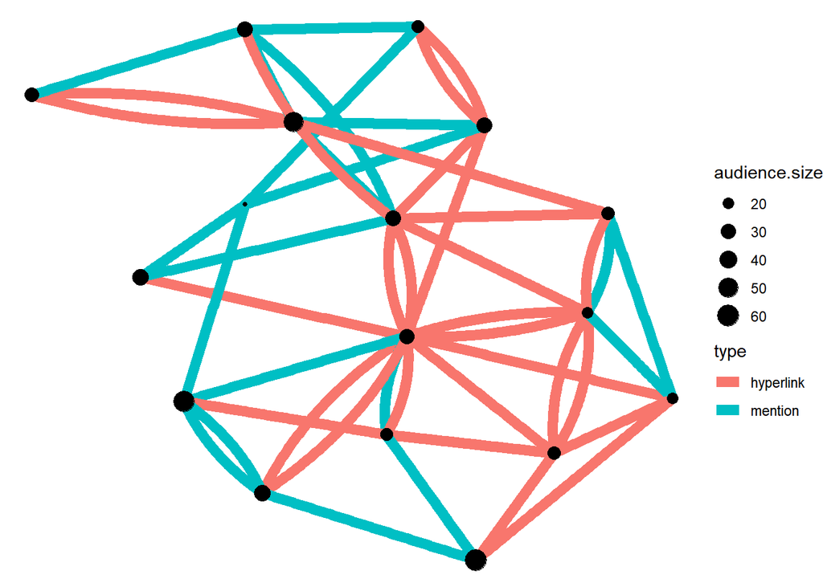

```r
# 添加其他视觉原件如图例
ggraph(net, layout="lgl") +
  geom_edge_fan(aes(color = type), width = 3) +
  geom_node_point(aes(size = audience.size)) +
  theme_void()
```

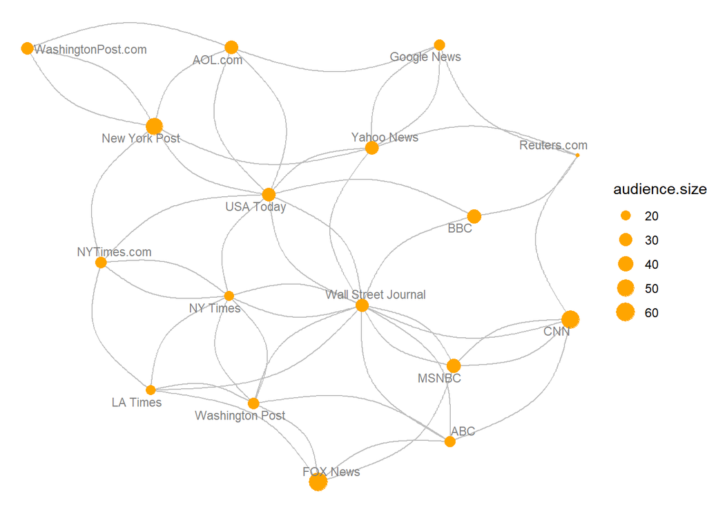

```r
# 我们可以使用geom_node_text()或geom_node_label()添加一个带有节点标签的层
ggraph(net,  layout = 'lgl') +
  geom_edge_arc(color="gray", curvature=0.3) +
  geom_node_point(color="orange", aes(size = audience.size)) +
  geom_node_text(aes(label = media), size=3, color="gray50", repel=T) +
  theme_void()
```

```r
detach("package:ggraph")
```